# Week 2, Wednesday Lecture Notes

Carole Voulgaris

9/9/2020

## Sample dataset

Here are the first few lines of a person-level dataset with five variables:

- Gender
- Employment status
- Income
- Population density within a mile of home
- Daily vehicle miles traveled

| ID | gender | employment | income | density | VMT |
| --- | --- | --- | --- | --- | --- |
| 1 | Female | Employed | 39621 | 9958 | 20.7 |
| 2 | Male | Employed | 50854 | 12032 | 23.8 |
| 3 | Female | Not in labor force | 17232 | 7537 | 16.1 |
| 4 | Male | Unemployed | 20925 | 9969 | 19.5 |
| 5 | Female | Employed | 34243 | 12332 | 20.2 |
| 6 | Female | Employed | 31866 | 6995 | 20.8 |
| 7 | Male | Not in labor force | 57368 | 10023 | 22.9 |

## Visualizing a continuous distribution

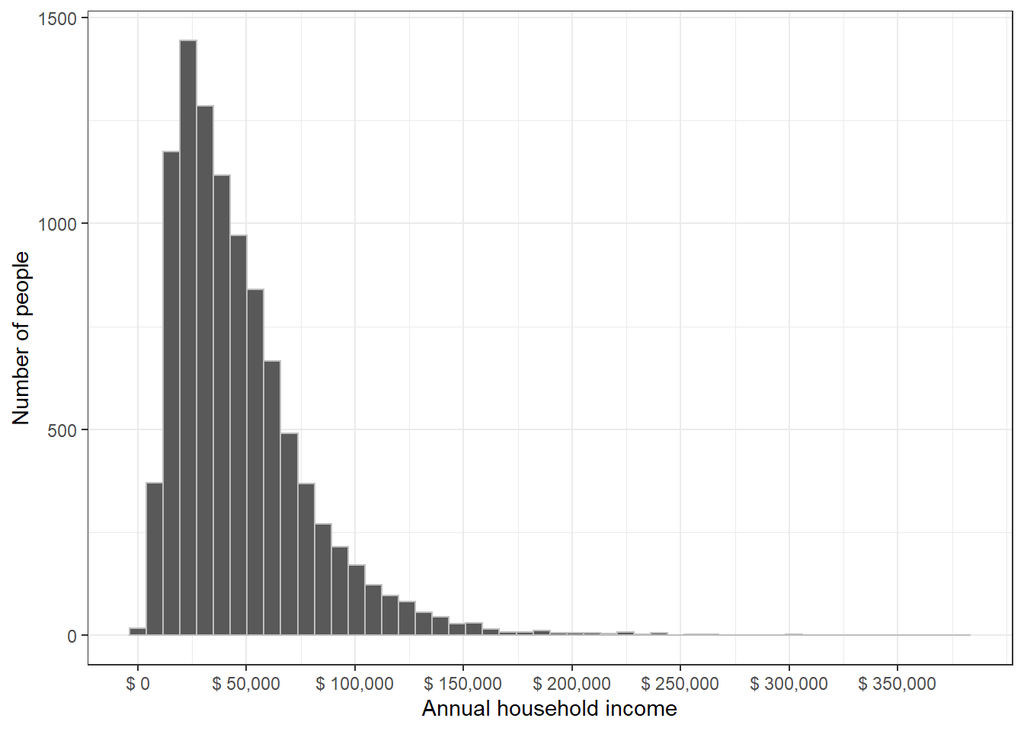

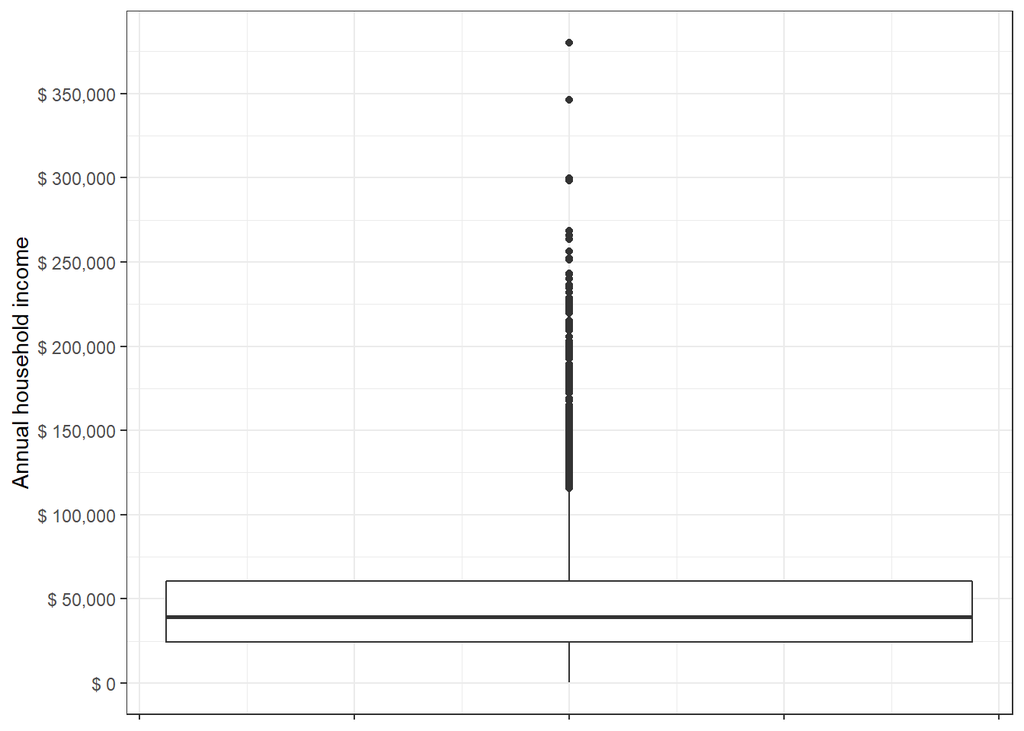

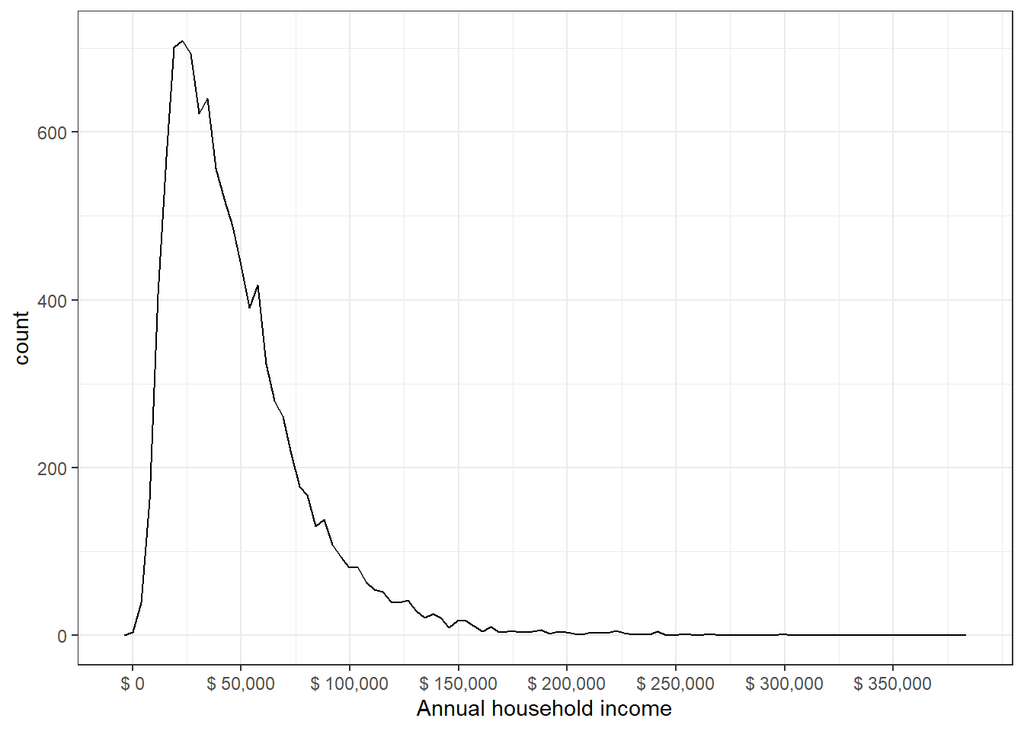

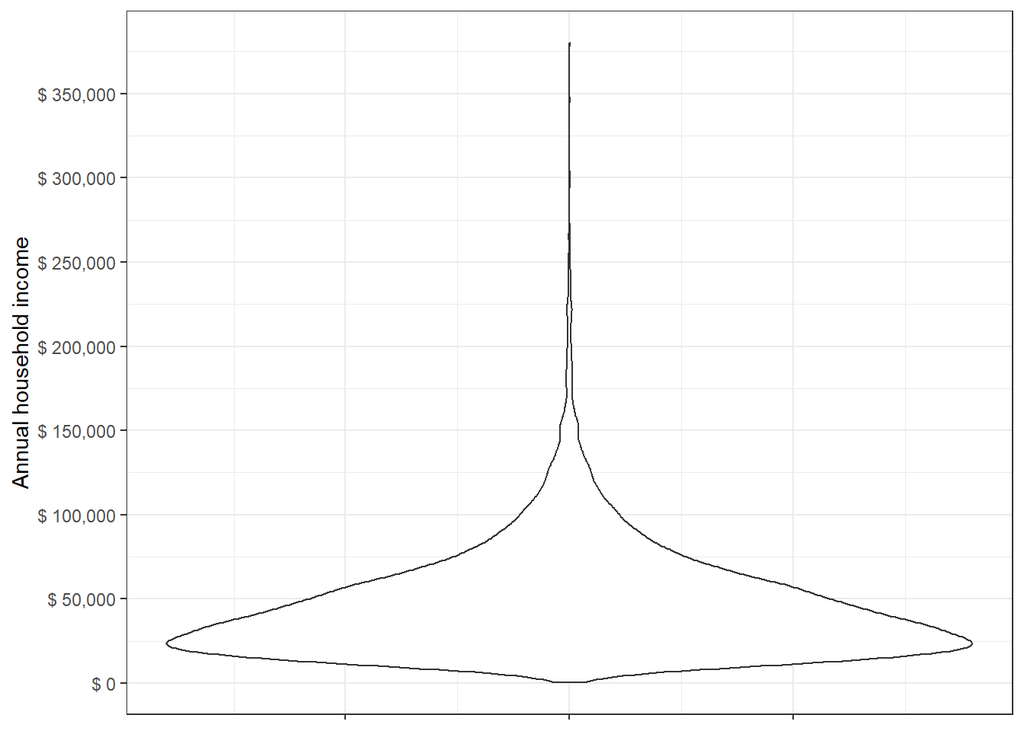

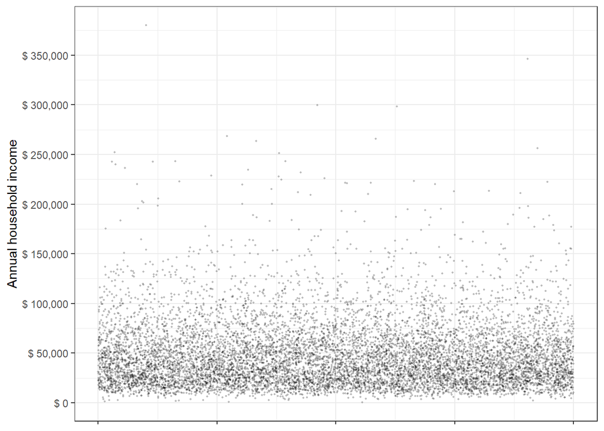

## Distributions of categorical variables

Here are three ways to visualize the distribution of a categorical variable. How else could you visualize these distributions? Why might you choose one option or another?

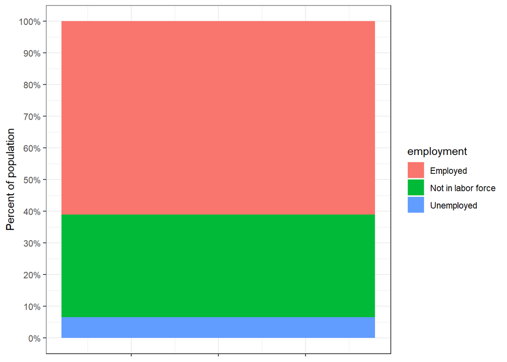

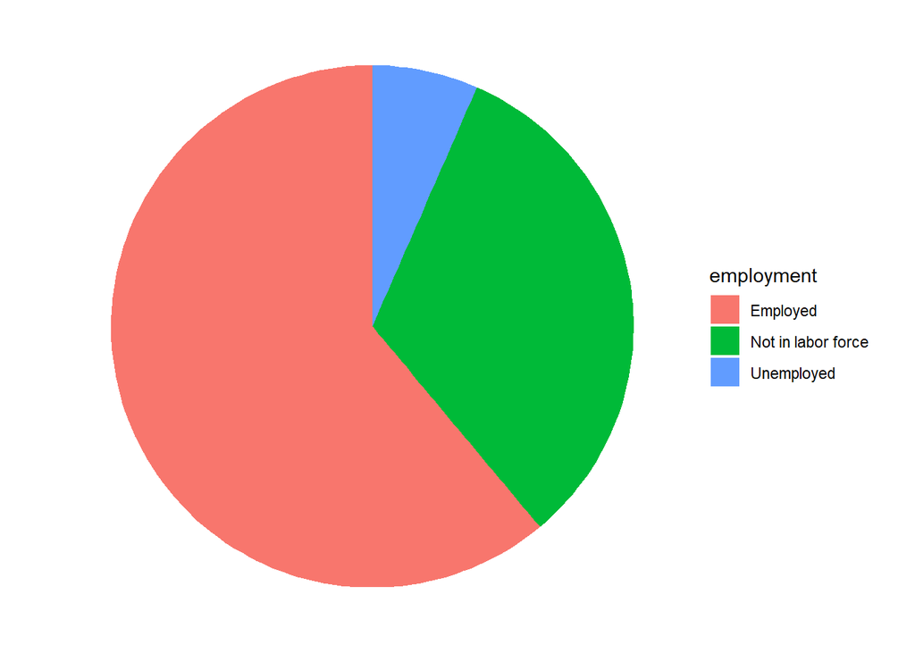

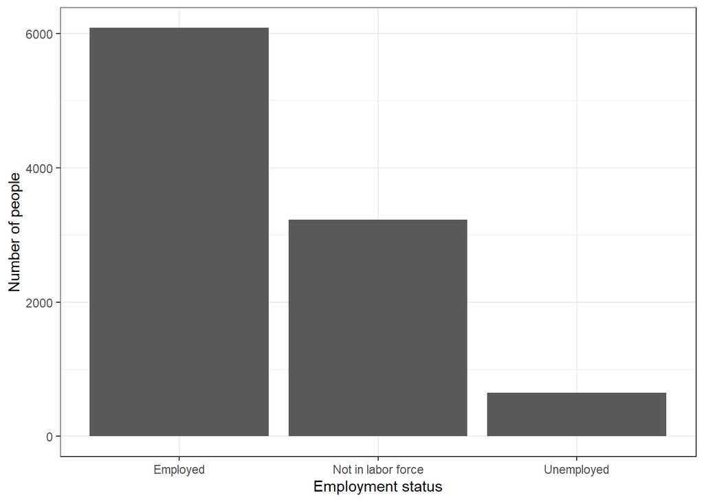

## Relationships between continuous variables

Here are some alternative representations of the relationship between VMT and income.

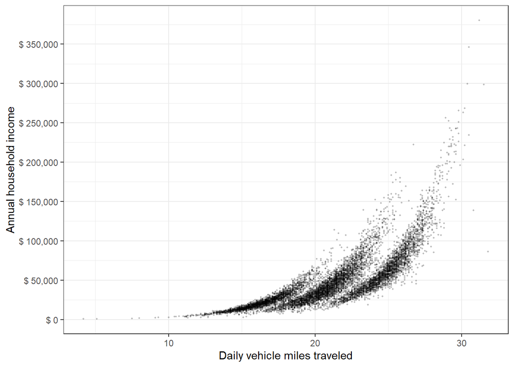

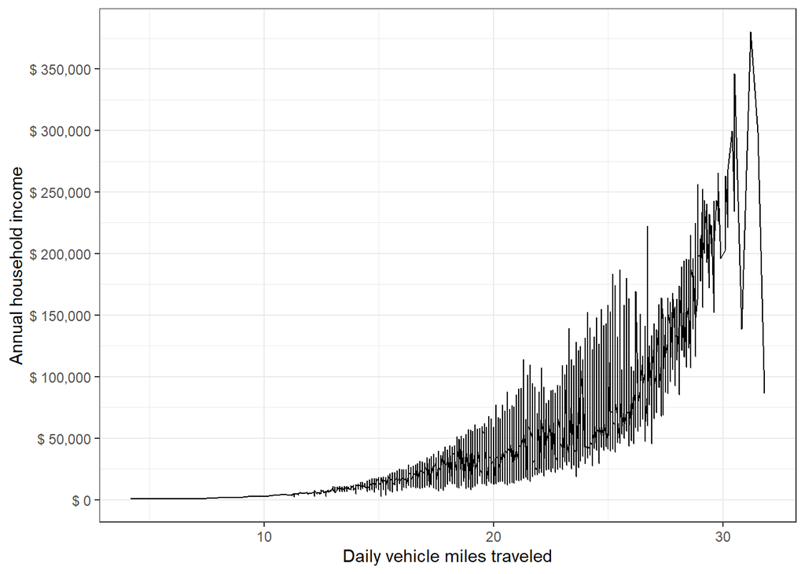

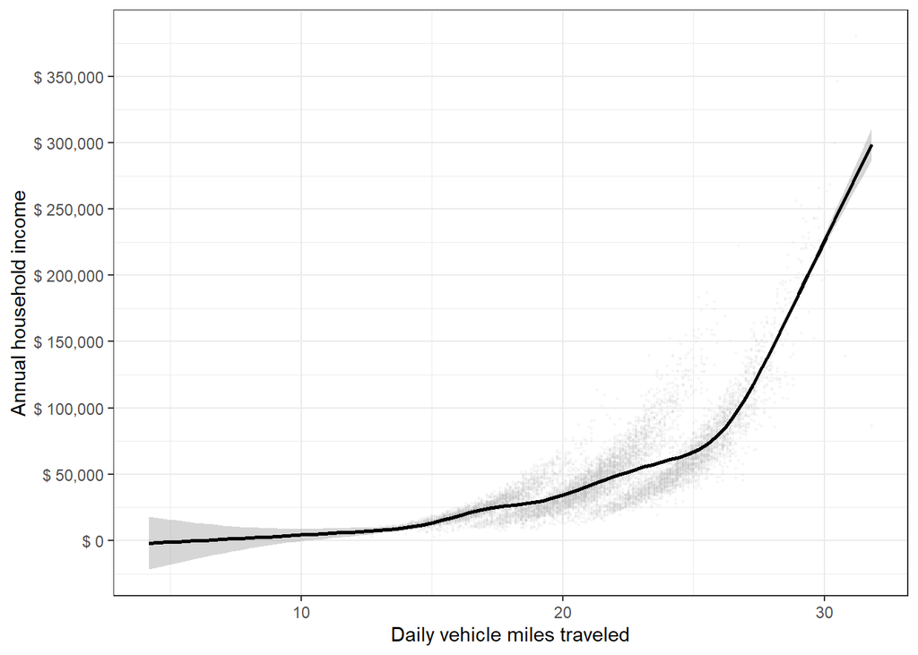

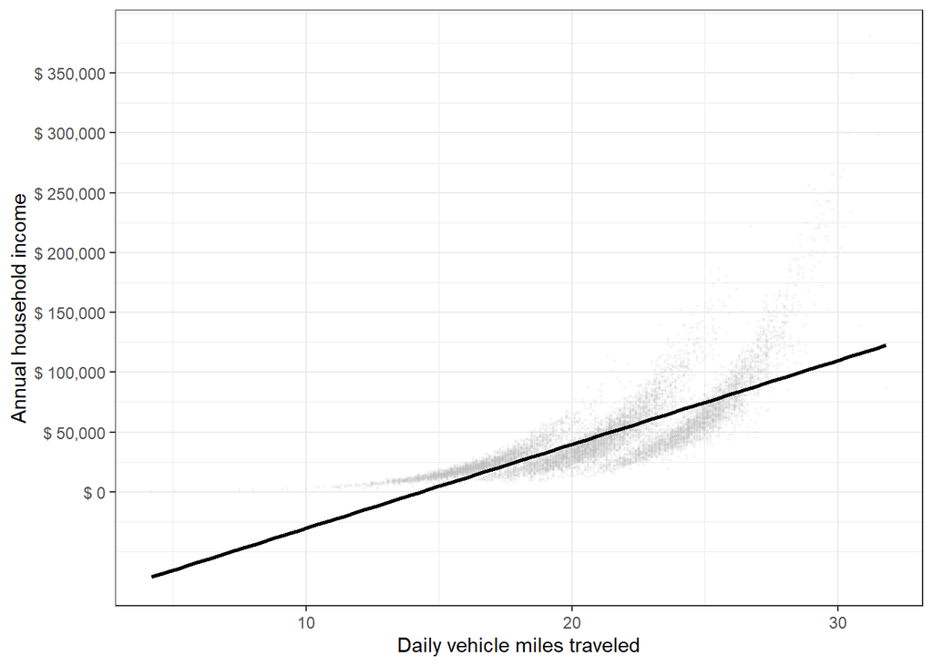

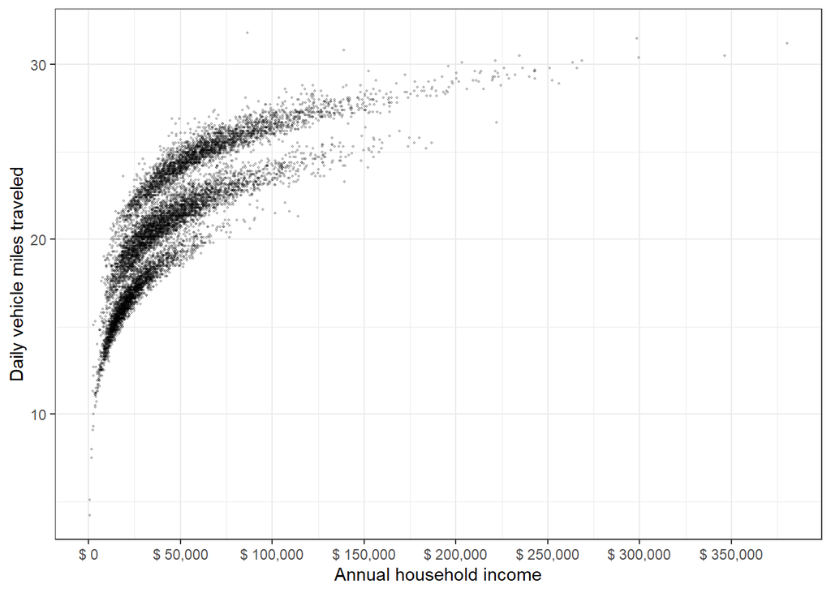

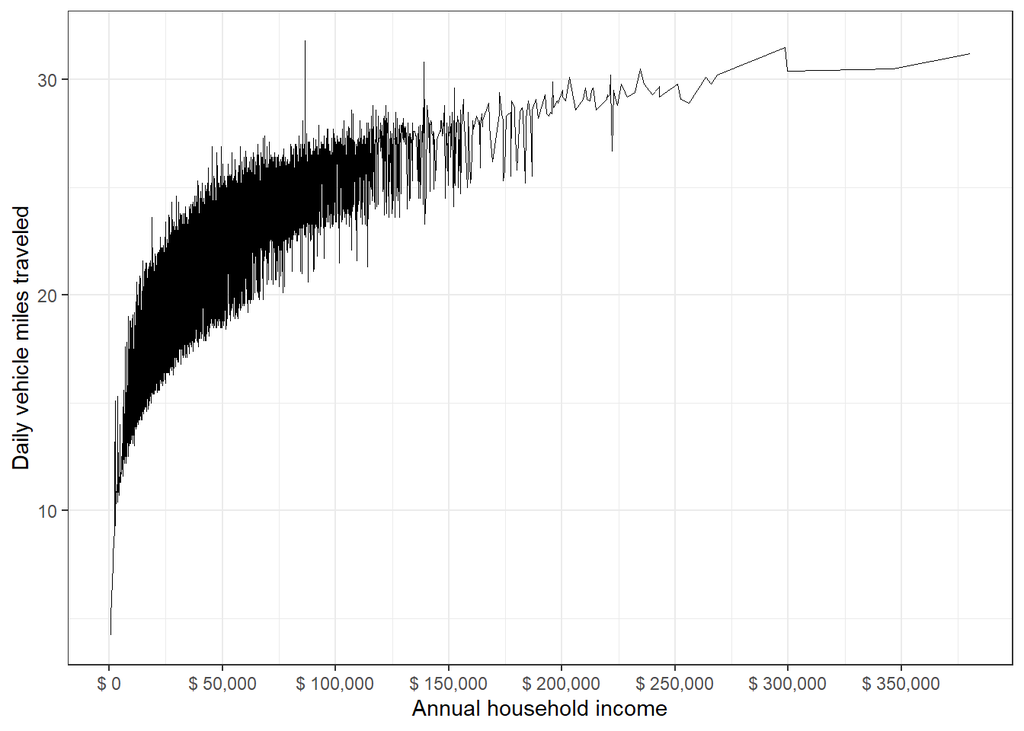

## Log scales and linear scale

All of the above example show income on a linear scale. What if we showed it on a log scale?

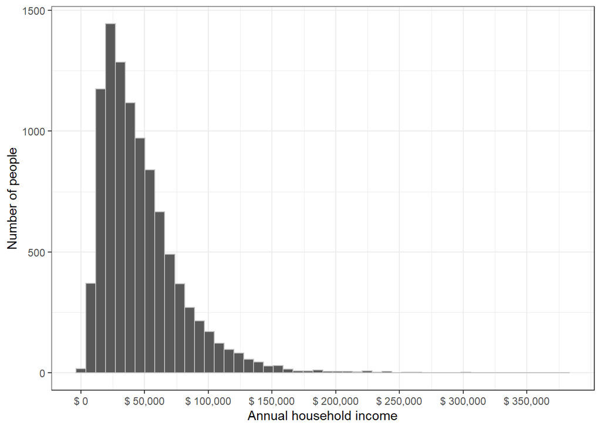

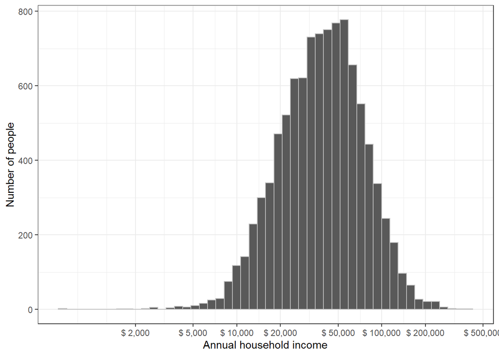

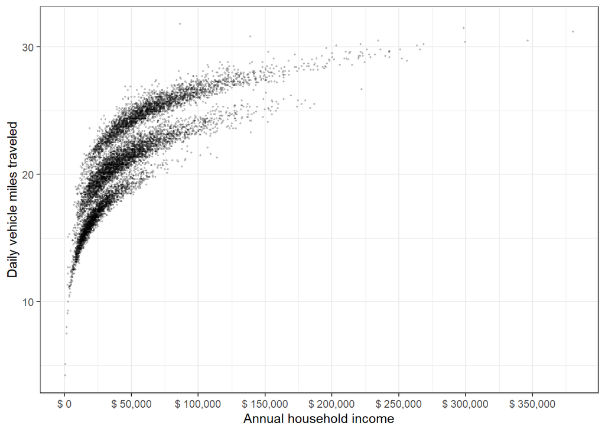

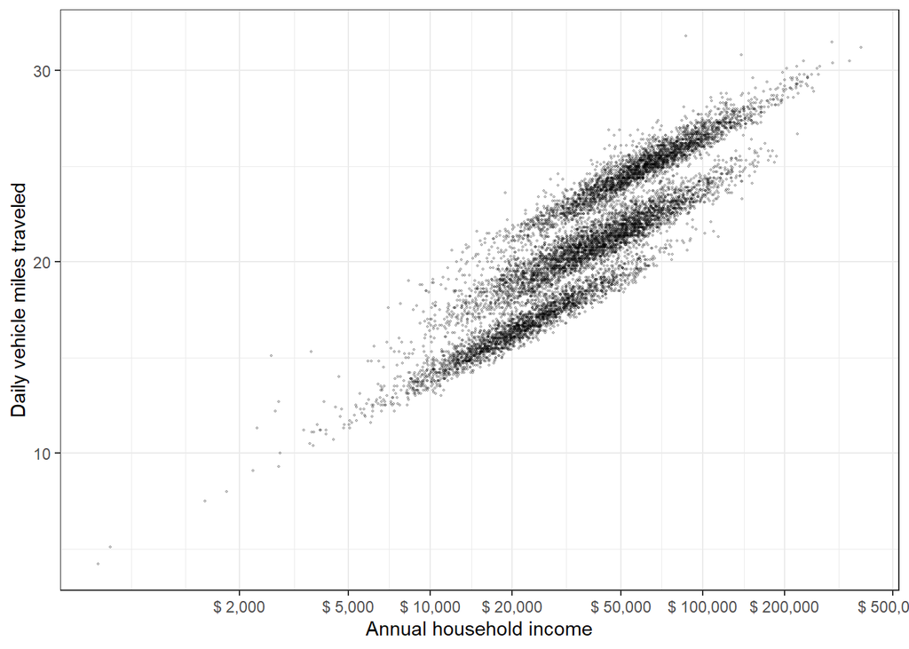

## Cartesian or Polar Coordinates?

Let’s look at some time-series data. Here are selected rows from a day-level dataset with five variables:

- Number of day since we started measuring total vehicle miles traveled
- Day of the week
- Day of the week (as a number)
- Week number
- Million Vehicle Miles Traveled in the city that day

| day_count | day | day_num | Week | MVMT |
| --- | --- | --- | --- | --- |
| 13 | Friday | 6 | 2 | 33.03017 |
| 14 | Saturday | 7 | 2 | 31.03017 |
| 15 | Sunday | 1 | 3 | 29.81867 |
| 16 | Monday | 2 | 3 | 31.81867 |
| 17 | Tuesday | 3 | 3 | 34.81867 |
| 18 | Wednesday | 4 | 3 | 35.81867 |
| 19 | Thursday | 5 | 3 | 35.21867 |
| 20 | Friday | 6 | 3 | 32.81867 |
| 21 | Saturday | 7 | 3 | 30.81867 |
| 22 | Sunday | 1 | 4 | 29.96563 |
| 23 | Monday | 2 | 4 | 31.96563 |
| 24 | Tuesday | 3 | 4 | 34.96563 |
| 25 | Wednesday | 4 | 4 | 35.96563 |
| 26 | Thursday | 5 | 4 | 35.36563 |

Here are some graphs that shows how MVMT has changed over time.

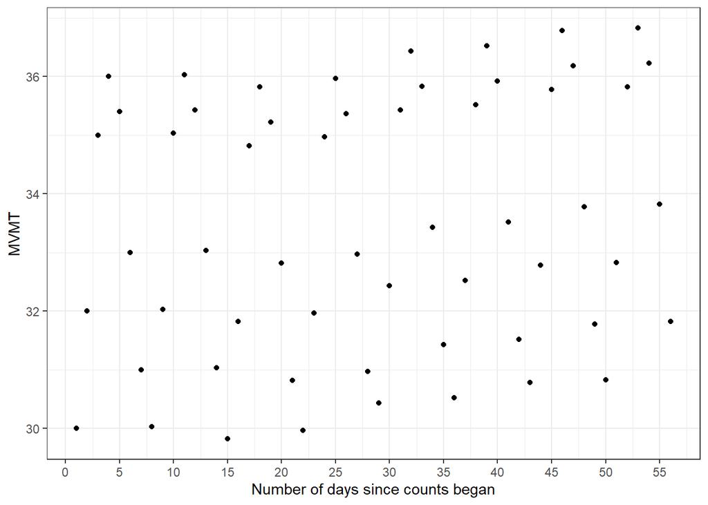

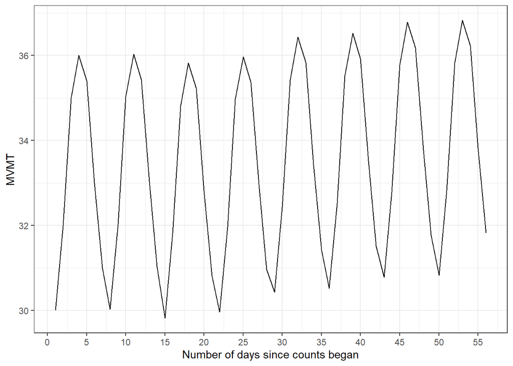

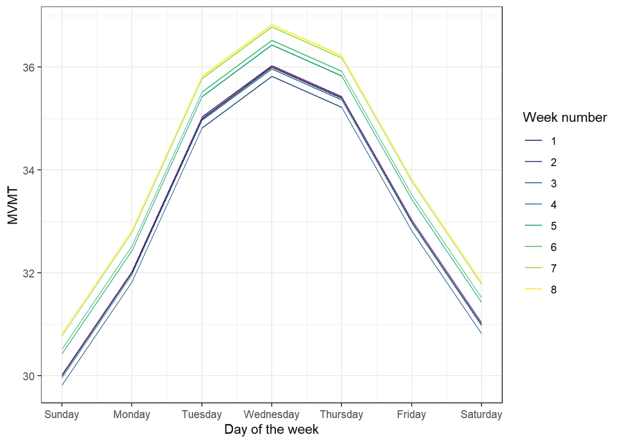

A polar coordinate system is useful for showing cycles:

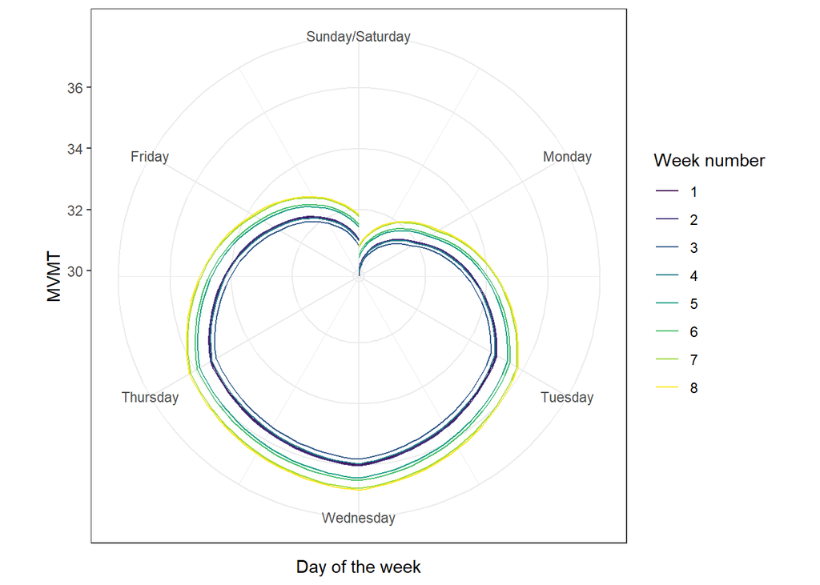

(Polar coodinates are also useful for pie charts)